# Elaboração de Gráficos com o Pacote ggplot2

O resultado visual vem abaixo:

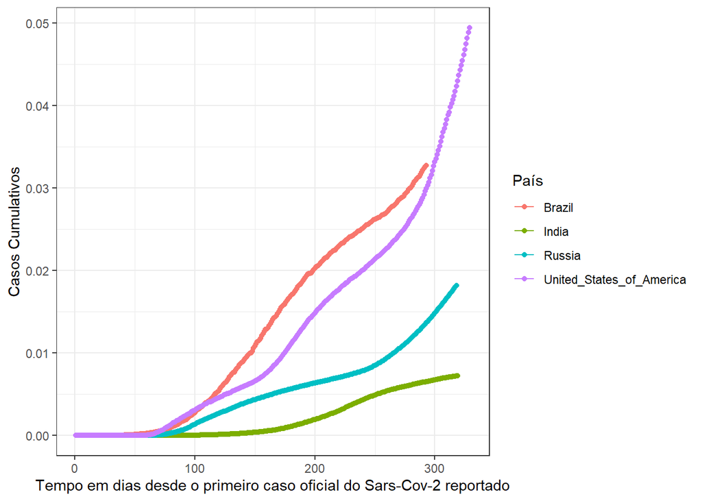

```r
ggplot(covid_110521) +
  geom_line(aes(x = t, y = pop_ccases, color = country)) +
  geom_point(aes(x = t, y = pop_ccases, color = country)) +
  labs(x = "Tempo em dias desde o primeiro caso oficial do Sars-Cov-2 reportado",
       y = "Casos Cumulativos",
       color = "País") +
  theme_bw()
```

Ainda assim, os gráficos não trazem uma informação importante: os valores dos casos cumulativos por dia e por país. Em regra, no ggplot, podemos utilizar a geometria ‘text’ para isso:

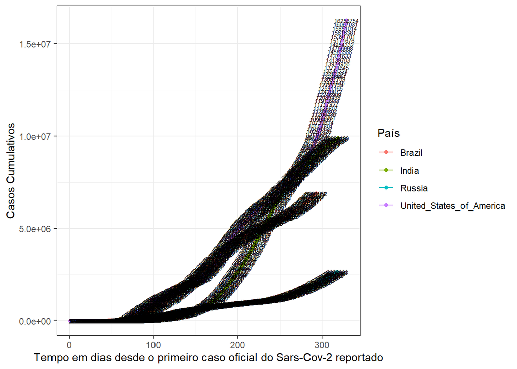

```r
ggplot(covid_110521) +
  geom_line(aes(x = t, y = cumulative_cases, color = country)) +
  geom_point(aes(x = t, y = cumulative_cases, color = country)) +
  geom_text(aes(x = t, y = cumulative_cases, label = cumulative_cases),
            color = "black", size = 2) +
  labs(x = "Tempo em dias desde o primeiro caso oficial do Sars-Cov-2 reportado",
       y = "Casos Cumulativos",
       color = "País") +
  theme_bw()
```

E se deslocássemos as labels dos valores dos casos cumulativos?

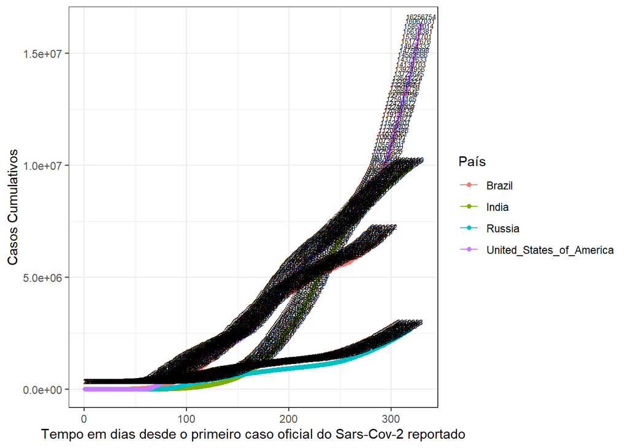

```r
ggplot(covid_110521) +
  geom_line(aes(x = t, y = cumulative_cases, color = country)) +
  geom_point(aes(x = t, y = cumulative_cases, color = country)) +
  geom_text(aes(x = t, y = cumulative_cases, label = cumulative_cases),
            color = "black", size = 2, vjust = -1) +
  labs(x = "Tempo em dias desde o primeiro caso oficial do Sars-Cov-2 reportado",
       y = "Casos Cumulativos",
       color = "País") +
  theme_bw()
```

Ainda está caótico, certo? E se alterássemos o ângulo de exibição das labels?

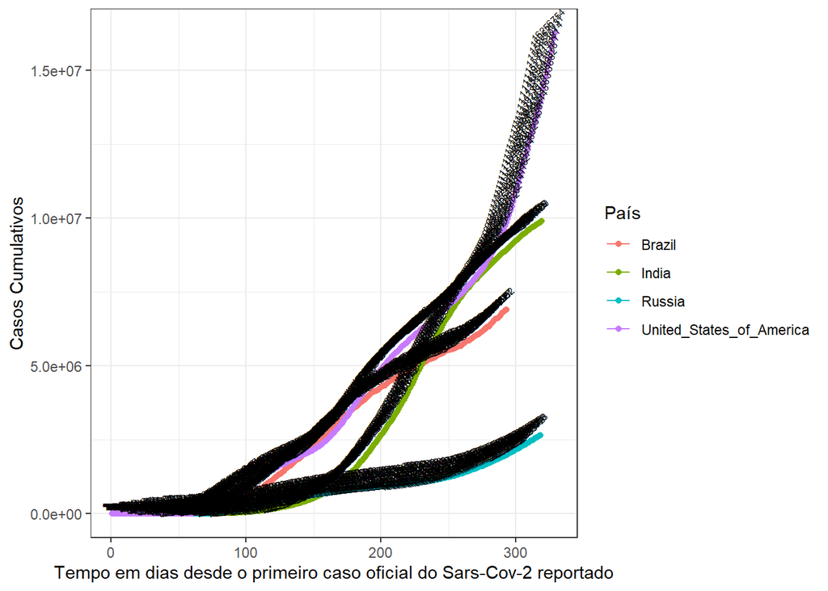

```r
ggplot(covid_110521) +
  geom_line(aes(x = t, y = cumulative_cases, color = country)) +
  geom_point(aes(x = t, y = cumulative_cases, color = country)) +
  geom_text(aes(x = t, y = cumulative_cases, label = cumulative_cases),
            color = "black", size = 2, vjust = -1, angle = 45) +
  labs(x = "Tempo em dias desde o primeiro caso oficial do Sars-Cov-2 reportado",
       y = "Casos Cumulativos",
       color = "País") +
  theme_bw()
```

Continua péssimo. São muitos dias e muitos países analisados ao mesmo tempo!

A função geom_text_repel() do pacote ‘ggrepel’, por vezes resolve o problema:

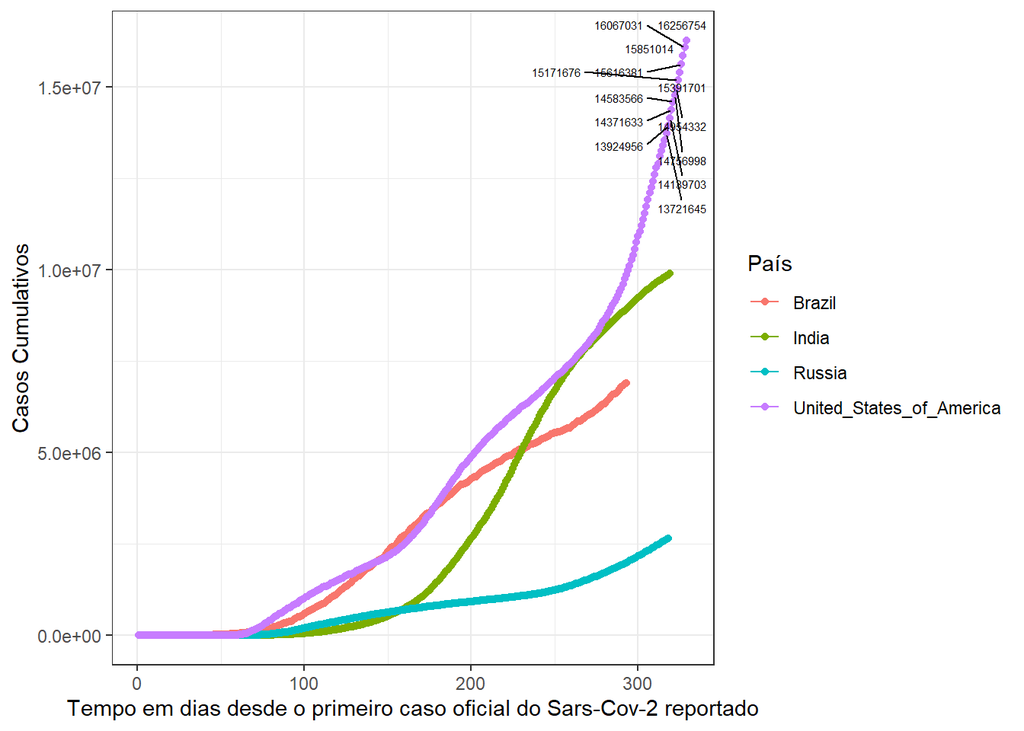

```r
ggplot(covid_110521) +
  geom_line(aes(x = t, y = cumulative_cases, color = country)) +
  geom_point(aes(x = t, y = cumulative_cases, color = country)) +
  geom_text_repel(aes(x = t, y = cumulative_cases, label = cumulative_cases),
                  color = "black", size = 2) +
  labs(x = "Tempo em dias desde o primeiro caso oficial do Sars-Cov-2 reportado",
       y = "Casos Cumulativos",
       color = "País") +
  theme_bw()
```

Dá até vontade de desistir, a gente sabe! Em casos extremos, como no exemplo apresentado, talvez seja melhor omitir as labels e deixar o gráfico interativo com o usuário da informação. Podemos fazer isso com a função ggplotly() do pacote ‘plotly’:

```r
ggplotly(
  ggplot(covid_110521) +
    geom_line(aes(x = t, y = cumulative_cases, color = country)) +
    geom_point(aes(x = t, y = cumulative_cases, color = country)) +
    labs(x = "Tempo em dias desde o primeiro caso oficial do Sars-Cov-2 reportado",
         y = "Casos Cumulativos",
         color = "País") +
    theme_bw()
)
```

[interactive chart not shown]

Agora passa passar o mouse pelo gráfico para ter acesso às informações necessárias!

Caso quiséssemos fazer uma análise diária, bastaria mudar a variável de interesse:

```r
ggplotly(
  ggplot(covid_110521) +
    geom_line(aes(x = t, y = daily_cases, color = country)) +
    geom_point(aes(x = t, y = daily_cases, color = country)) +
    labs(x = "Tempo em dias desde o primeiro caso oficial do Sars-Cov-2 reportado",
         y = "Casos Diários",
         color = "País") +
    theme_bw()
)
```

[interactive chart not shown]

# Mapas de Calor

Nosso principal exemplo para gráficos de calor para hoje será a respeito da relação entre variáveis. Entre variáveis métricas, essas relações se chamam correlações, cuja fórmula do coeficiente de correlação de Pearson segue a seguir:

$\rho = \frac{\sum_{i=1}^{n}(X_{i}-\bar{X}).(Y_{i}-\bar{Y})}{\sqrt{\sum_{i=1}^{n}(X_{i}-\bar{X})^2.\sqrt{\sum_{i=1}^{n}(Y_{i}-\bar{Y})^2}}}$

Assim, primeiro vamos observar alguns gráficos correlacionais com a função chart.Correlation() do pacote ’PerformanceAnalytics”:

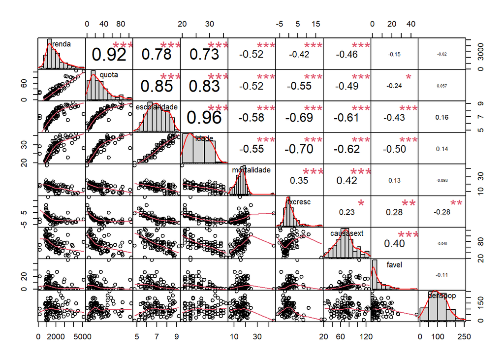

```r
chart.Correlation(atlas_ambiental[, 3:11], histogram = T)
```

Para criarmos um gráfico de calor a respeito das correlações da nossa base de dados, o primeiro passo é estabelecer uma Matriz de Correlações. Podemos fazer isso utilizando a função cor() da linguagem básica do R:

```r
matriz_correlacoes <- cor(atlas_ambiental[, 3:11])

matriz_correlacoes
```

```
##                    renda       quota escolaridade      idade mortalidade
## renda         1.00000000  0.92009937    0.7773322  0.7323071 -0.51958497
## quota         0.92009937  1.00000000    0.8504546  0.8327369 -0.52028200
## escolaridade  0.77733216  0.85045460    1.0000000  0.9558249 -0.58260085
## idade         0.73230705  0.83273686    0.9558249  1.0000000 -0.55375832
## mortalidade  -0.51958497 -0.52028200   -0.5826008 -0.5537583  1.00000000
## txcresc      -0.42471079 -0.55476724   -0.6929676 -0.7032367  0.34604928
## causasext    -0.46251567 -0.49101971   -0.6066208 -0.6150734  0.42278951
## favel        -0.14695749 -0.24301018   -0.4325480 -0.4998385  0.13087742
## denspop      -0.01971076  0.05737442    0.1576728  0.1414692 -0.09301763
##                 txcresc   causasext      favel     denspop
## renda        -0.4247108 -0.46251567 -0.1469575 -0.01971076
## quota        -0.5547672 -0.49101971 -0.2430102  0.05737442
## escolaridade -0.6929676 -0.60662084 -0.4325480  0.15767283
## idade        -0.7032367 -0.61507339 -0.4998385  0.14146917
## mortalidade   0.3460493  0.42278951  0.1308774 -0.09301763
## txcresc       1.0000000  0.23447240  0.2818525 -0.27908375
## causasext     0.2344724  1.00000000  0.4044469 -0.04528098
## favel         0.2818525  0.40444685  1.0000000 -0.10648120
## denspop      -0.2790838 -0.04528098 -0.1064812  1.00000000
```

Para o caso dos gráficos de calor, é melhor que a base de dados esteja no formato long em vez do formato wide. Podemos alterar isso com a função melt() do pacote ‘reshape2’

```r
correlacoes <- melt(matriz_correlacoes)

head(correlacoes)
```

```
##           Var1  Var2      value
## 1        renda renda  1.0000000
## 2        quota renda  0.9200994
## 3 escolaridade renda  0.7773322
## 4        idade renda  0.7323071
## 5  mortalidade renda -0.5195850
## 6      txcresc renda -0.4247108
```

```r
tail(correlacoes)
```

```
##           Var1    Var2       value
## 76       idade denspop  0.14146917
## 77 mortalidade denspop -0.09301763
## 78     txcresc denspop -0.27908375
## 79   causasext denspop -0.04528098
## 80       favel denspop -0.10648120
## 81     denspop denspop  1.00000000
```

Aqui, nós vamos alterar os nomes das variáveis do nosso novo objeto que demos o nome de ‘correlacoes’:

```r
names(correlacoes) <- c("var1", "var2", "correlacao")

correlacoes
```

```
##            var1         var2  correlacao
## 1         renda        renda  1.00000000
## 2         quota        renda  0.92009937
## 3  escolaridade        renda  0.77733216
## 4         idade        renda  0.73230705
## 5   mortalidade        renda -0.51958497
## 6       txcresc        renda -0.42471079
## 7     causasext        renda -0.46251567
## 8         favel        renda -0.14695749
## 9       denspop        renda -0.01971076
## 10        renda        quota  0.92009937
## 11        quota        quota  1.00000000
## 12 escolaridade        quota  0.85045460
## 13        idade        quota  0.83273686
## 14  mortalidade        quota -0.52028200
```

[output cut: 67 more lines]

Agora sim, aplicando a sintaxe básica do ggplot2, temos:

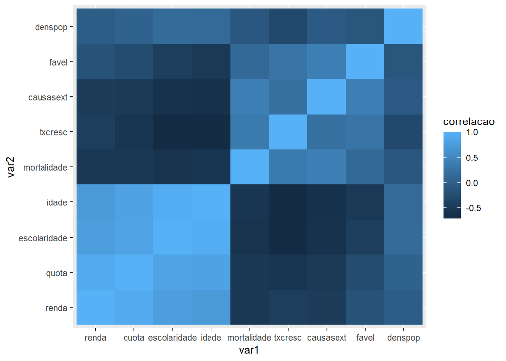

```r
ggplot(correlacoes) +
  geom_tile(aes(x = var1, y = var2, fill = correlacao))
```

Podemos remover os nomes dos eixos do gráfico da seguinte forma:

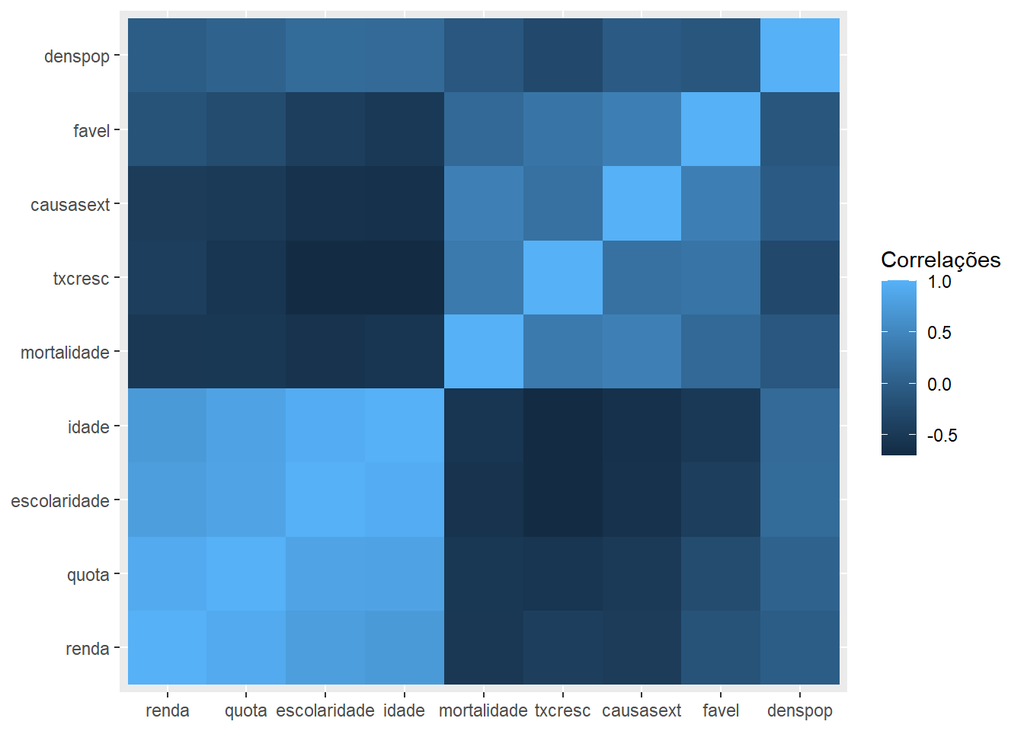

```r
ggplot(correlacoes) +
  geom_tile(aes(x = var1, y = var2, fill = correlacao)) +
  labs(x = NULL,
       y = NULL,
       fill = "Correlações")
```

Podemos criar um gradiente de cores, da seguinte maneira:

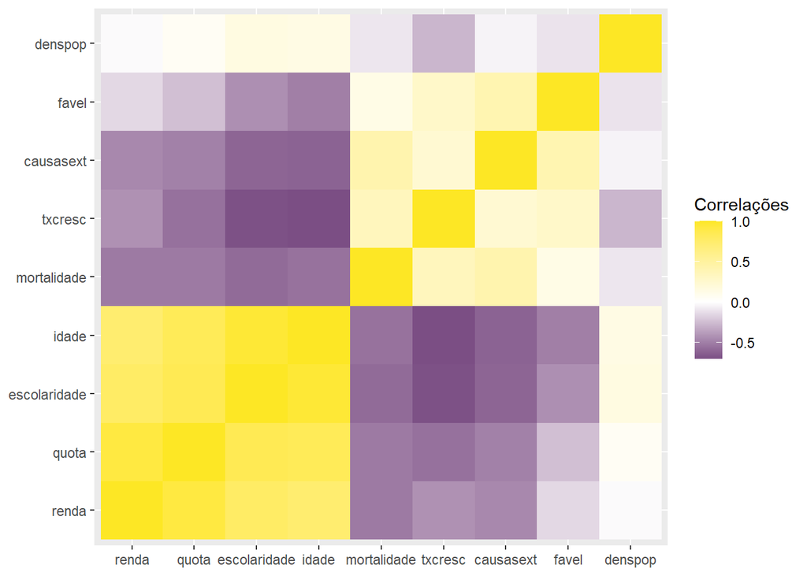

```r
ggplot(correlacoes) +
  geom_tile(aes(x = var1, y = var2, fill = correlacao)) +
  labs(x = NULL,
       y = NULL,
       fill = "Correlações") +
  scale_fill_gradient2(low = "#440154FF",
                       mid = "white",
                       high = "#FDE725FF",
                       midpoint = 0)
```

Podemos incluir os valores de cada correlação em cada quadrícula:

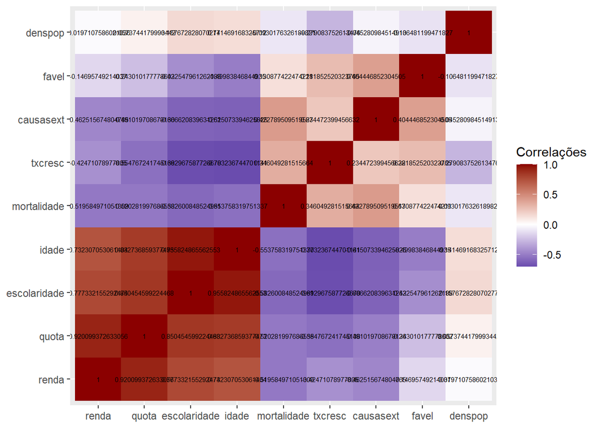

```r
ggplot(correlacoes) +
  geom_tile(aes(x = var1, y = var2, fill = correlacao)) +
  geom_text(aes(x = var1, y = var2, label = correlacao), size = 2) +
  labs(x = NULL,
       y = NULL,
       fill = "Correlações") +
  scale_fill_gradient2(low = "darkblue",
                       mid = "white",
                       high = "darkred",
                       midpoint = 0)
```

Os valores das correlações estão muito extensos, certo? Basta aplicarmos um arredondamento a eles com a função round():

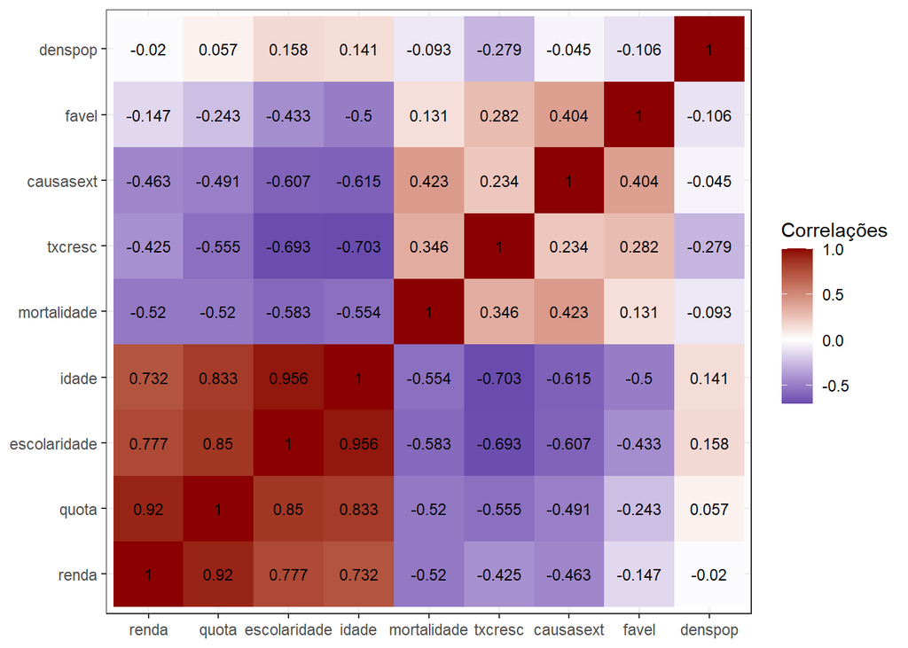

```r
ggplot(correlacoes) +
  geom_tile(aes(x = var1, y = var2, fill = correlacao)) +
  geom_text(aes(x = var1, y = var2, label = round(correlacao, digits = 3)),
            size = 3) +
  labs(x = NULL,
       y = NULL,
       fill = "Correlações") +
  scale_fill_gradient2(low = "darkblue",
                       mid = "white",
                       high = "darkred",
                       midpoint = 0) +
  theme_bw()
```

Lembra da ggplotly() do pacote ‘plotly’? Pois é! Podemos aplicá-la aqui também!

```r
ggplotly(
  ggplot(correlacoes) +
    geom_tile(aes(x = var1, y = var2, fill = correlacao)) +
    geom_text(aes(x = var1, y = var2,
                  label = round(correlacao, digits = 3)),
              size = 3) +
    labs(x = NULL,
         y = NULL,
         fill = "Correlações") +
    scale_fill_gradient2(low = "darkblue",
                         mid = "white",
                         high = "darkred",
                         midpoint = 0) +
    theme_bw()
)
```

[interactive chart not shown]

Os nomes das variáveis estão sobrepostos no eixo das abcissas. Podemos resolver isso com argumentos à função theme():

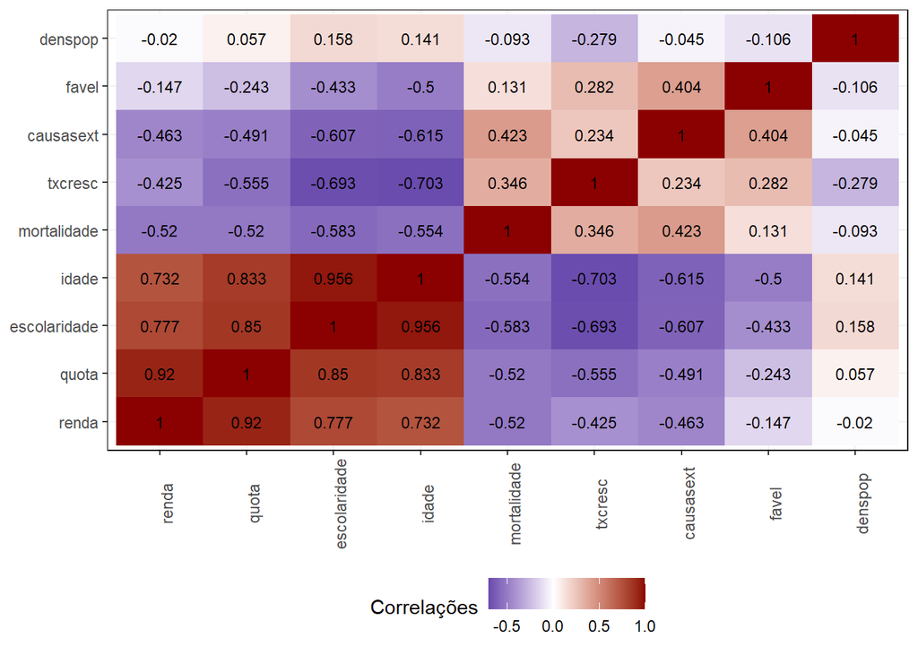

```r
ggplot(correlacoes) +
    geom_tile(aes(x = var1, y = var2, fill = correlacao)) +
    geom_text(aes(x = var1, y = var2, label = round(correlacao,
                                                    digits = 3)),
              size = 3) +
    labs(x = NULL,
         y = NULL,
         fill = "Correlações") +
    scale_fill_gradient2(low = "darkblue",
                         mid = "white",
                         high = "darkred",
                         midpoint = 0) +
    theme(panel.background = element_rect("white"),
        panel.grid = element_line("grey95"),
        panel.border = element_rect(NA),
        legend.position = "bottom",
        axis.text.x = element_text(angle = 90))
```

# Boxplot

No R, para construir alguns boxplots, é melhor que utilizemos nossas bases de dados no formato long. Basta utilizarmos a função melt() do pacote ‘reshape2’:

```r
atlas_long <- melt(atlas_ambiental[, 2:11], id.vars = "distritos")

head(atlas_long)
```

```
##           distritos variable value
## 1         Água Rasa    renda  1961
## 2 Alto de Pinheiros    renda  4180
## 3        Anhanguera    renda  1093
## 4        Aricanduva    renda  1311
## 5       Artur Alvim    renda  1248
## 6       Barra Funda    renda  2359
```

```r
tail(atlas_long)
```

```
##         distritos variable  value
## 859  Vila Matilde  denspop 111.70
## 860 Vila Medeiros  denspop 188.93
## 861 Vila Prudente  denspop 101.44
## 862    Vila Sônia  denspop  80.12
## 863  São Domingos  denspop  72.92
## 864       Lajeado  denspop 141.01
```

Agora sim, podemos plotar nossos dados:

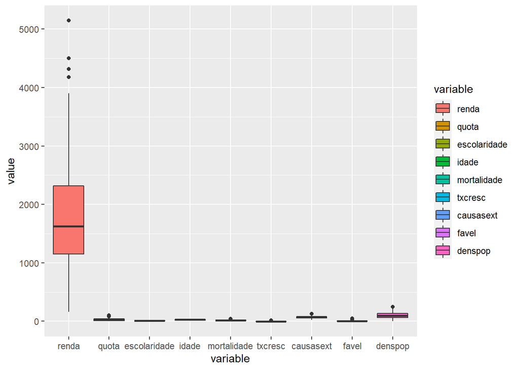

```r
ggplot(atlas_long) +
  geom_boxplot(aes(x = variable, y = value, fill = variable))
```

A visualização ficou diferente do esperado, não é? Você consegue dizer a razão disso?

O problema está na comparação de variáveis com tipos distintos de magnitude.

Podemos resolver a situação padronizando as variáveis com o procedimento zscores, por exemplo:

$zX_{i}=\frac{X_{i}-\bar{X}}{\sigma}$

```r
atlas_padronizado <- atlas_ambiental

atlas_padronizado[, 3:11] <- scale(atlas_padronizado[, 3:11])

head(atlas_padronizado)
```

```
## # A tibble: 6 x 11
##   cód_ibge distritos       renda  quota escolaridade   idade mortalidade txcresc
##   <chr>    <chr>           <dbl>  <dbl>        <dbl>   <dbl>       <dbl>   <dbl>
## 1 1        Água Rasa       0.108  0.180       0.520   1.05        -0.427  -0.536
## 2 2        Alto de Pinhe~  2.39   1.97        1.31    1.28        -1.46   -0.730
## 3 3        Anhanguera     -0.786 -1.13       -1.26   -1.00        -0.127   5.15
## 4 4        Aricanduva     -0.562 -0.411      -0.273  -0.0903       0.488  -0.317
## 5 5        Artur Alvim    -0.627 -0.632      -0.0743 -0.0903       0.748  -0.411
## 6 6        Barra Funda     0.518  0.166       0.917   0.822       -1.48   -0.621
## # ... with 3 more variables: causasext <dbl>, favel <dbl>, denspop <dbl>
```

```r
tail(atlas_padronizado)
```

```
## # A tibble: 6 x 11
##   cód_ibge distritos      renda   quota escolaridade   idade mortalidade txcresc
##   <chr>    <chr>          <dbl>   <dbl>        <dbl>   <dbl>       <dbl>   <dbl>
## 1 91       Vila Matilde  -0.336 -0.194         0.322  0.366        0.628  -0.533
## 2 92       Vila Medeiros -0.465 -0.465        -0.273 -0.0903      -0.113  -0.413
## 3 93       Vila Prudente -0.104  0.0695        0.124  0.594       -0.327  -0.738
## 4 94       Vila Sônia     1.15   0.474         0.322 -0.0903       0.154  -0.268
## 5 95       São Domingos   0.197 -0.302        -0.273 -0.318       -0.339   0.191
## 6 96       Lajeado       -1.11  -0.954        -1.66  -1.46         0.532   0.795
## # ... with 3 more variables: causasext <dbl>, favel <dbl>, denspop <dbl>
```

Como já visto, devemos transformar nossa base de dados em formato long:

```r
atlas_padronizado_long <- melt(atlas_padronizado[, 2:11],
                               id.vars = "distritos")

head(atlas_padronizado_long)
```

```
##           distritos variable      value
## 1         Água Rasa    renda  0.1079357
## 2 Alto de Pinheiros    renda  2.3937396
## 3        Anhanguera    renda -0.7861958
## 4        Aricanduva    renda -0.5616328
## 5       Artur Alvim    renda -0.6265294
## 6       Barra Funda    renda  0.5179177
```

```r
tail(atlas_padronizado_long)
```

```
##         distritos variable       value
## 859  Vila Matilde  denspop  0.23867472
## 860 Vila Medeiros  denspop  1.79551721
## 861 Vila Prudente  denspop  0.03184841
## 862    Vila Sônia  denspop -0.39793125
## 863  São Domingos  denspop -0.54307270
## 864       Lajeado  denspop  0.82952092
```

Vamos tentar, mais uma vez, utilizar a sintaxe básica do ggplot2 para a construção de boxplots:

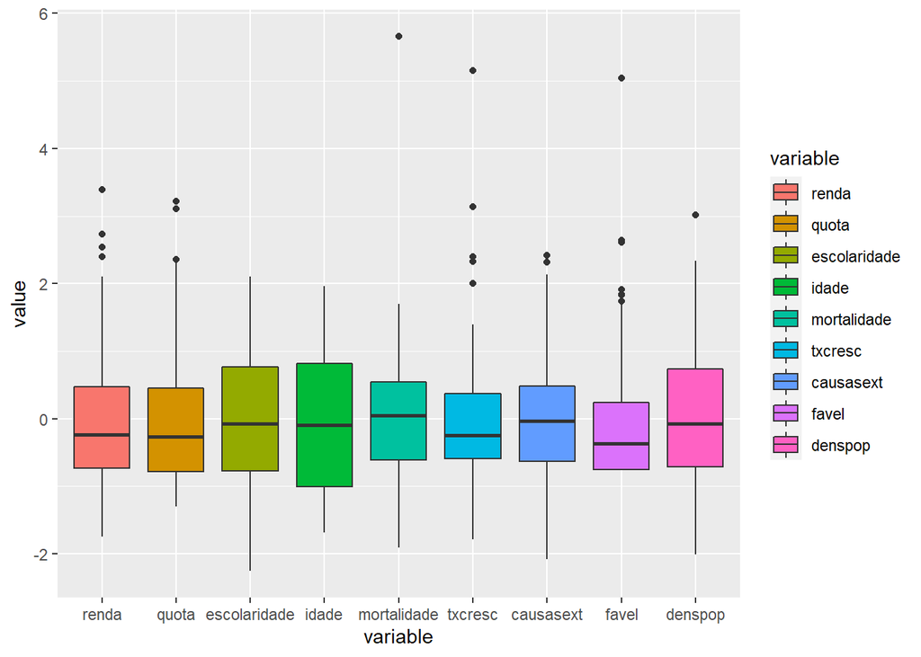

```r
ggplot(atlas_padronizado_long) +
  geom_boxplot(aes(x = variable, y = value, fill = variable))
```

Podemos deixar o gráfico mais elegante nomeando os eixos, alterando o plano de fundo e removendo a legenda:

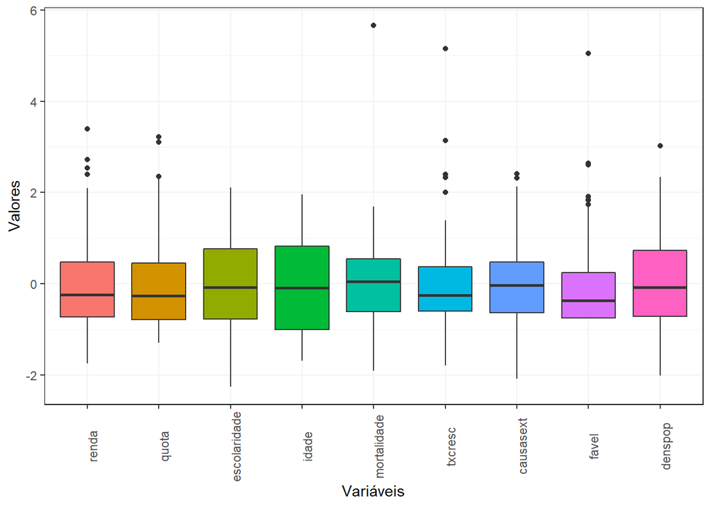

```r
ggplot(atlas_padronizado_long) +
  geom_boxplot(aes(x = variable, y = value, fill = variable)) +
  labs(x = "Variáveis",
       y = "Valores") +
  theme(panel.background = element_rect("white"),
        panel.grid = element_line("grey95"),
        panel.border = element_rect(NA),
        legend.position = "none",
        axis.text.x = element_text(angle = 90))
```

Com objetivos puramente didáticos, podemos visualizar cada observação de cada variável padronizada da seguinte maneira:

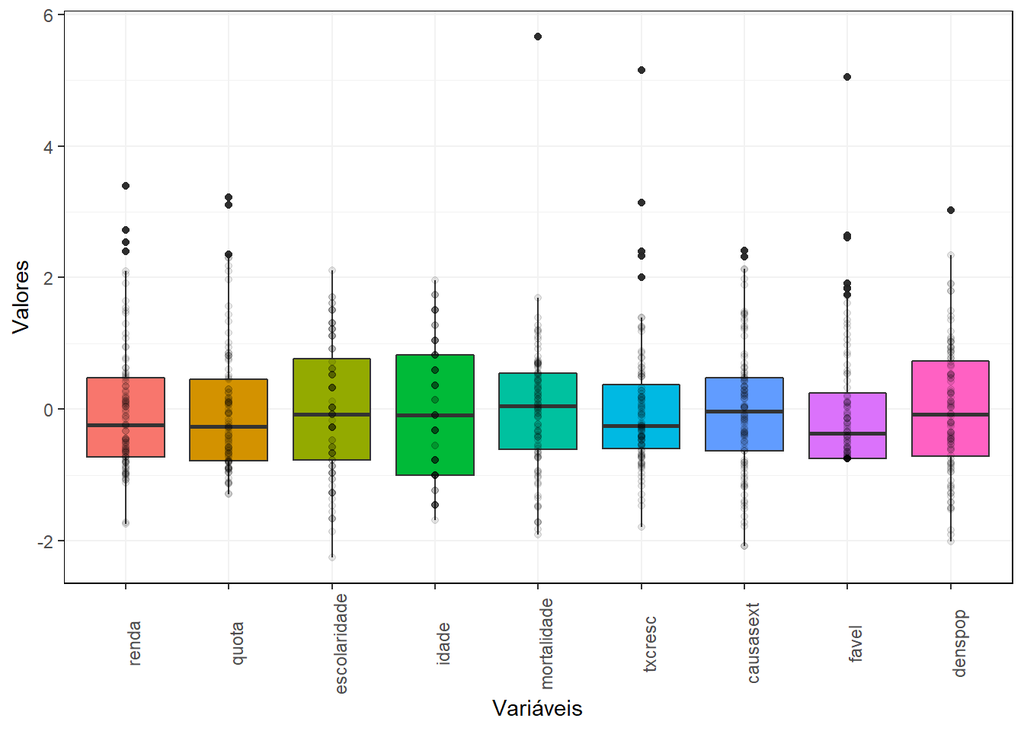

```r
ggplot(atlas_padronizado_long) +
  geom_boxplot(aes(x = variable, y = value, fill = variable)) +
  geom_point(aes(x = variable, y = value), alpha = 0.1) +
  labs(x = "Variáveis",
       y = "Valores") +
  theme(panel.background = element_rect("white"),
        panel.grid = element_line("grey95"),
        panel.border = element_rect(NA),
        legend.position = "none",
        axis.text.x = element_text(angle = 90))
```

E sim! Podemos deixas nossos boxplots interativos com ajuda do pacote ‘plotly’

```r
ggplotly(
  ggplot(atlas_padronizado_long) +
    geom_boxplot(aes(x = variable, y = value, fill = variable)) +
    labs(x = "Variáveis",
         y = "Valores") +
    theme_bw()
)
```

[interactive chart not shown]